# Individual differences

In **Pilot 1**, there are 41 subjects who did the curiosity personal trait questionaire. The following analysis will only include these subjects who had personal trait scores.

# 1 Relationship between trait score and slope of curiosity-memory relationship

## 1.1 Outside

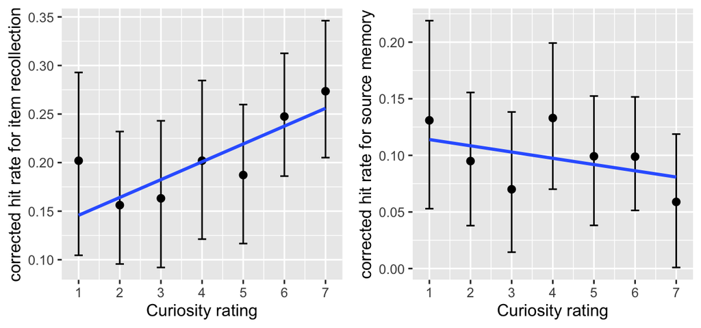

### 1.1.1 Item recollection

#### 1.1.1.1 Correlation with the average score

```
##                  Model df       AIC       BIC   logLik   Test  L.Ratio
## baseline.rating      1  3 -75.73959 -65.27278 40.86980
## rating.intercept     2  4 -79.74151 -65.78576 43.87076 1 vs 2 6.001920
## rating.slope         3  6 -79.85212 -58.91849 45.92606 2 vs 3 4.110605
## tr.intercept         4  7 -78.13068 -53.70811 46.06534 3 vs 4 0.278558
## tr.slope             5  8 -76.34812 -48.43662 46.17406 4 vs 5 0.217442
##                  p-value
## baseline.rating
## rating.intercept  0.0143
## rating.slope      0.1281
## tr.intercept      0.5976
## tr.slope          0.6410
```

#### 1.1.1.2 Correlation with the PC score

```
##                  Model df       AIC       BIC   logLik   Test  L.Ratio
## baseline.rating      1  3 -75.73959 -65.27278 40.86980
## rating.intercept     2  4 -79.74151 -65.78576 43.87076 1 vs 2 6.001920
## rating.slope         3  6 -79.85212 -58.91849 45.92606 2 vs 3 4.110605
## PC.intercept         4  7 -78.71043 -54.28787 46.35522 3 vs 4 0.858316
## PC.slope             5  8 -76.73465 -48.82315 46.36733 4 vs 5 0.024218
##                  p-value
## baseline.rating
## rating.intercept  0.0143
## rating.slope      0.1281
## PC.intercept      0.3542
## PC.slope          0.8763
```

#### 1.1.1.3 Correlation with the EC score

```
##                  Model df       AIC       BIC   logLik   Test  L.Ratio
## baseline.rating      1  3 -75.73959 -65.27278 40.86980
## rating.intercept     2  4 -79.74151 -65.78576 43.87076 1 vs 2 6.001920
## rating.slope         3  6 -79.85212 -58.91849 45.92606 2 vs 3 4.110605
## EC.intercept         4  7 -77.85261 -53.43004 45.92630 3 vs 4 0.000491
## EC.slope             5  8 -76.85853 -48.94703 46.42926 4 vs 5 1.005918
##                  p-value
## baseline.rating
## rating.intercept  0.0143
## rating.slope      0.1281
## EC.intercept      0.9823
## EC.slope          0.3159
```

### 1.1.2 Source memory

#### 1.1.2.1 Correlation with the average score

```
##                  Model df       AIC        BIC   logLik   Test   L.Ratio
## baseline.rating      1  3 -133.8400 -123.37321 69.92001
## rating.intercept     2  4 -132.6069 -118.65116 70.30346 1 vs 2 0.7668956
## rating.slope         3  6 -128.6068 -107.67319 70.30341 2 vs 3 0.0000972
## tr.intercept         4  7 -128.0341 -103.61150 71.01703 3 vs 4 1.4272483
## tr.slope             5  8 -126.6972  -98.78569 71.34859 4 vs 5 0.6631223
##                  p-value
## baseline.rating
## rating.intercept  0.3812
## rating.slope      1.0000
## tr.intercept      0.2322
## tr.slope          0.4155
```

#### 1.1.2.2 Correlation with the PC score

```
##                  Model df       AIC       BIC   logLik   Test   L.Ratio
## baseline.rating      1  3 -133.8400 -123.3732 69.92001
## rating.intercept     2  4 -132.6069 -118.6512 70.30346 1 vs 2 0.7668956
## rating.slope         3  6 -128.6068 -107.6732 70.30341 2 vs 3 0.0000972
## PC.intercept         4  7 -127.9176 -103.4950 70.95880 3 vs 4 1.3107759
## PC.slope             5  8 -126.7668  -98.8553 71.38340 4 vs 5 0.8492107
##                  p-value
## baseline.rating
## rating.intercept  0.3812
## rating.slope      1.0000
## PC.intercept      0.2523
## PC.slope          0.3568
```

#### 1.1.2.3 Correlation with the EC score

```
##                  Model df       AIC        BIC   logLik   Test   L.Ratio
## baseline.rating      1  3 -133.8400 -123.37321 69.92001
## rating.intercept     2  4 -132.6069 -118.65116 70.30346 1 vs 2 0.7668956
## rating.slope         3  6 -128.6068 -107.67319 70.30341 2 vs 3 0.0000972
## EC.intercept         4  7 -127.6520 -103.22943 70.82600 3 vs 4 1.0451748
## EC.slope             5  8 -125.8790  -97.96748 70.93949 4 vs 5 0.2269925
##                  p-value
## baseline.rating
## rating.intercept  0.3812
## rating.slope      1.0000
## EC.intercept      0.3066
## EC.slope          0.6338
```

## 1.2 Inside

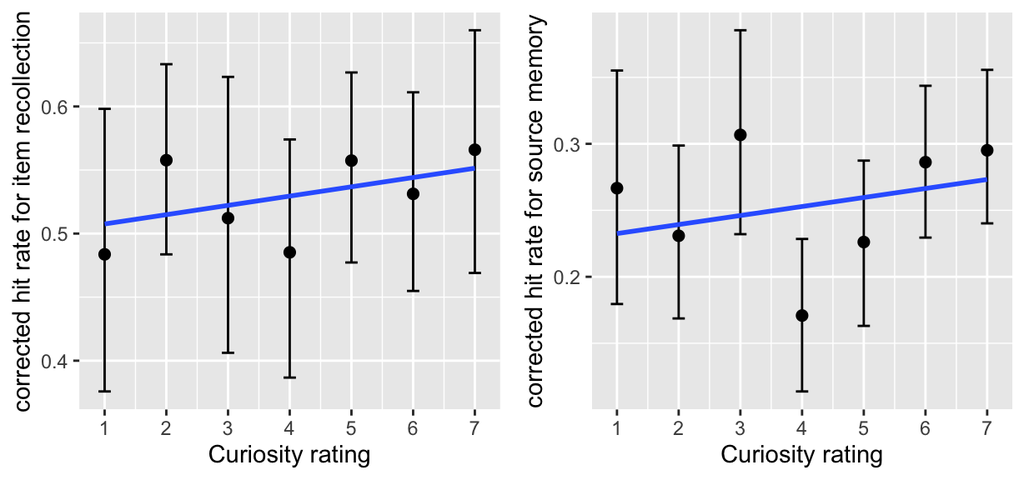

### 1.2.1 Item recollection

#### 1.2.1.1 Correlation with the average score

```
##                  Model df        AIC       BIC    logLik   Test  L.Ratio
## baseline.rating      1  3 -13.121985 -2.655172  9.560993
## rating.intercept     2  4 -11.991718  1.964033  9.995859 1 vs 2 0.869732
## rating.slope         3  6  -9.275989 11.657637 10.637995 2 vs 3 1.284272
## tr.intercept         4  7  -7.432811 16.989754 10.716405 3 vs 4 0.156821
## tr.slope             5  8 -12.002484 15.909018 14.001242 4 vs 5 6.569673
##                  p-value
## baseline.rating
## rating.intercept  0.3510
## rating.slope      0.5262
## tr.intercept      0.6921
## tr.slope          0.0104
```

```
##                    Value  Std.Error  DF    t-value     p-value
## (Intercept)   0.03995129 0.24413896 199  0.1636416 0.870179356
## CurRating     0.12343365 0.04629233 199  2.6663955 0.008297419
## GN            0.16136376 0.08361566  39  1.9298270 0.060925130
## CurRating:GN -0.04042677 0.01576016 199 -2.5651239 0.011050240
```

#### 1.2.1.2 Correlation with the PC score

```
##                  Model df        AIC       BIC    logLik   Test  L.Ratio
## baseline.rating      1  3 -13.121985 -2.655172  9.560993
## rating.intercept     2  4 -11.991718  1.964033  9.995859 1 vs 2 0.869732
## rating.slope         3  6  -9.275989 11.657637 10.637995 2 vs 3 1.284272
## PC.intercept         4  7  -8.221841 16.200723 11.110920 3 vs 4 0.945851
## PC.slope             5  8 -12.673641 15.237861 14.336821 4 vs 5 6.451801
##                  p-value
## baseline.rating
## rating.intercept  0.3510
## rating.slope      0.5262
## PC.intercept      0.3308
## PC.slope          0.0111
```

```
##                    Value  Std.Error  DF     t-value     p-value
## (Intercept)  -0.01536758 0.22475156 199 -0.06837585 0.945555096
## CurRating     0.11346796 0.04241009 199  2.67549449 0.008083252
## PC            0.17907611 0.07610445  39  2.35303088 0.023758714
## CurRating:PC -0.03670825 0.01427999 199 -2.57060786 0.010882449
```

#### 1.2.1.3 Correlation with the EC score

```
##                  Model df        AIC       BIC    logLik   Test  L.Ratio
## baseline.rating      1  3 -13.121985 -2.655172  9.560993
## rating.intercept     2  4 -11.991718  1.964033  9.995859 1 vs 2 0.869732
## rating.slope         3  6  -9.275989 11.657637 10.637995 2 vs 3 1.284272
## EC.intercept         4  7  -7.369596 17.052968 10.684798 3 vs 4 0.093606
## EC.slope             5  8  -9.652841 18.258660 12.826421 4 vs 5 4.283246
##                  p-value
## baseline.rating
## rating.intercept  0.3510
## rating.slope      0.5262
## EC.intercept      0.7596
## EC.slope          0.0385
```

```
##                    Value  Std.Error  DF   t-value    p-value
## (Intercept)   0.25685147 0.21852658 199  1.175379 0.24124763
## CurRating     0.09060554 0.04158638 199  2.178731 0.03052660
## EC            0.08680904 0.07525360  39  1.153553 0.25570411
## CurRating:EC -0.02933373 0.01423352 199 -2.060891 0.04061384
```

### 1.2.2 Source memory

#### 1.2.2.1 Correlation with the average score

```
##                  Model df       AIC       BIC   logLik   Test   L.Ratio
## baseline.rating      1  3 -94.13752 -83.67070 50.06876
## rating.intercept     2  4 -93.78851 -79.83276 50.89426 1 vs 2 1.6509941
## rating.slope         3  6 -92.25693 -71.32330 52.12846 2 vs 3 2.4684147
## tr.intercept         4  7 -90.25726 -65.83470 52.12863 3 vs 4 0.0003345
## tr.slope             5  8 -89.07050 -61.15900 52.53525 4 vs 5 0.8132398
##                  p-value
## baseline.rating
## rating.intercept  0.1988
## rating.slope      0.2911
## tr.intercept      0.9854
## tr.slope          0.3672
```

#### 1.2.2.2 Correlation with the PC score

```
##                  Model df       AIC       BIC   logLik   Test   L.Ratio
## baseline.rating      1  3 -94.13752 -83.67070 50.06876
## rating.intercept     2  4 -93.78851 -79.83276 50.89426 1 vs 2 1.6509941
## rating.slope         3  6 -92.25693 -71.32330 52.12846 2 vs 3 2.4684147
## PC.intercept         4  7 -90.96858 -66.54601 52.48429 3 vs 4 0.7116531
## PC.slope             5  8 -89.00685 -61.09535 52.50343 4 vs 5 0.0382741
##                  p-value
## baseline.rating
## rating.intercept  0.1988
## rating.slope      0.2911
## PC.intercept      0.3989
## PC.slope          0.8449
```

```
##                  Value   Std.Error  DF   t-value   p-value
## (Intercept) 0.12495449 0.106304557 200 1.1754387 0.2412167
## CurRating   0.01001817 0.007788641 200 1.2862540 0.1998414
## PC          0.02868865 0.034035621  39 0.8429008 0.4044239
```

#### 1.2.2.3 Correlation with the EC score

```
##                  Model df       AIC       BIC   logLik   Test   L.Ratio
## baseline.rating      1  3 -94.13752 -83.67070 50.06876
## rating.intercept     2  4 -93.78851 -79.83276 50.89426 1 vs 2 1.6509941
## rating.slope         3  6 -92.25693 -71.32330 52.12846 2 vs 3 2.4684147
## EC.intercept         4  7 -91.04653 -66.62396 52.52326 3 vs 4 0.7896003
## EC.slope             5  8 -91.09060 -63.17910 53.54530 4 vs 5 2.0440746
##                  p-value
## baseline.rating
## rating.intercept  0.1988
## rating.slope      0.2911
## EC.intercept      0.3742
## EC.slope          0.1528
```

# 2 Relationship between trait score and curiosity ratings

## 2.1 Across all the rooms

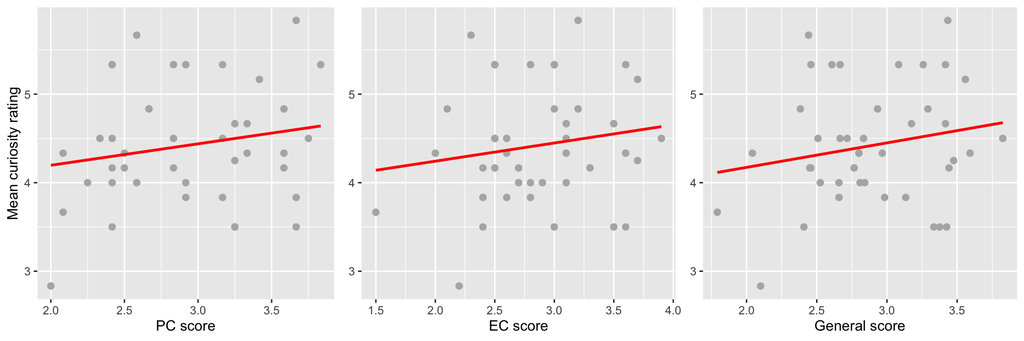

```r
cor.test(trait.ratings$meanCurRating, trait.ratings$PC, method = "pearson")
```

```
##
##  Pearson's product-moment correlation
##
## data:  trait.ratings$meanCurRating and trait.ratings$PC
## t = 1.1936, df = 39, p-value = 0.2398
## alternative hypothesis: true correlation is not equal to 0
## 95 percent confidence interval:
##  -0.1272648  0.4683367
## sample estimates:
##      cor
## 0.187736
```

```r
cor.test(trait.ratings$meanCurRating, trait.ratings$EC, method = "pearson")
```

```
##
##  Pearson's product-moment correlation
##
## data:  trait.ratings$meanCurRating and trait.ratings$EC
## t = 1.0136, df = 39, p-value = 0.317
## alternative hypothesis: true correlation is not equal to 0
## 95 percent confidence interval:
##  -0.1550854  0.4458826
## sample estimates:
##      cor
## 0.160209
```

```r
cor.test(trait.ratings$meanCurRating, trait.ratings$GN, method = "pearson")
```

```
##
##  Pearson's product-moment correlation
##
## data:  trait.ratings$meanCurRating and trait.ratings$GN
## t = 1.2316, df = 39, p-value = 0.2255
## alternative hypothesis: true correlation is not equal to 0
## 95 percent confidence interval:
##  -0.1213936  0.4729792
## sample estimates:
##       cor
## 0.1934828
```

## 2.2 Only for the *novel* rooms

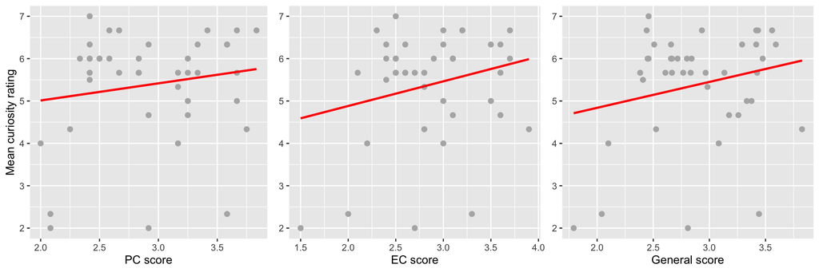

```
##
##  Pearson's product-moment correlation
##
## data:  trait.ratings.novel$meanCurRating and trait.ratings.novel$PC
## t = 1.0311, df = 39, p-value = 0.3089
## alternative hypothesis: true correlation is not equal to 0
## 95 percent confidence interval:
##  -0.1523898  0.4480918
## sample estimates:
##       cor
## 0.1628978
```

```
##
##  Pearson's product-moment correlation
##
## data:  trait.ratings.novel$meanCurRating and trait.ratings.novel$EC
## t = 1.5156, df = 39, p-value = 0.1377
## alternative hypothesis: true correlation is not equal to 0
## 95 percent confidence interval:
##  -0.0774208  0.5067301
## sample estimates:
##       cor
## 0.2358472
```

```
##
##  Pearson's product-moment correlation
##
## data:  trait.ratings.novel$meanCurRating and trait.ratings.novel$GN
## t = 1.4213, df = 39, p-value = 0.1632
## alternative hypothesis: true correlation is not equal to 0
## 95 percent confidence interval:
##  -0.09201643  0.49572239
## sample estimates:
##       cor
## 0.2219162
```

# 3 Relationship between trait score and memory performance

Here *memory performance* refers to the average corrected hit rate for “seen” response for items and average corrected hit rate for source memory.

## 3.1 Outside

### 3.1.1 Item recollection

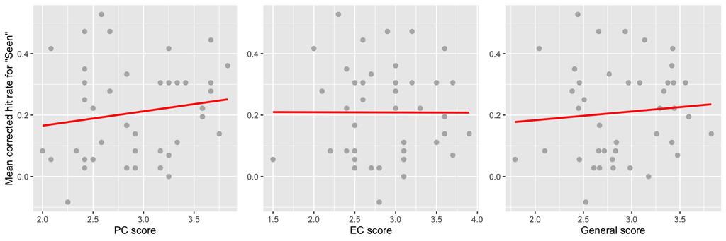

```
##
##  Pearson's product-moment correlation
##
## data:  outside.hit.rate.trait$meanSAcc and outside.hit.rate.trait$PC
## t = 1.0051, df = 39, p-value = 0.321
## alternative hypothesis: true correlation is not equal to 0
## 95 percent confidence interval:
##  -0.1563928  0.4448084
## sample estimates:
##       cor
## 0.1589032
```

```
##
##  Pearson's product-moment correlation
##
## data:  outside.hit.rate.trait$meanSAcc and outside.hit.rate.trait$EC
## t = -0.014875, df = 39, p-value = 0.9882
## alternative hypothesis: true correlation is not equal to 0
## 95 percent confidence interval:
##  -0.3098054  0.3054924
## sample estimates:
##         cor
## -0.00238194
```

```
##
##  Pearson's product-moment correlation
##
## data:  outside.hit.rate.trait$meanSAcc and outside.hit.rate.trait$GN
## t = 0.54395, df = 39, p-value = 0.5896
## alternative hypothesis: true correlation is not equal to 0
## 95 percent confidence interval:
##  -0.2269349  0.3841684
## sample estimates:
##        cor
## 0.08677376
```

### 3.1.2 Source memory

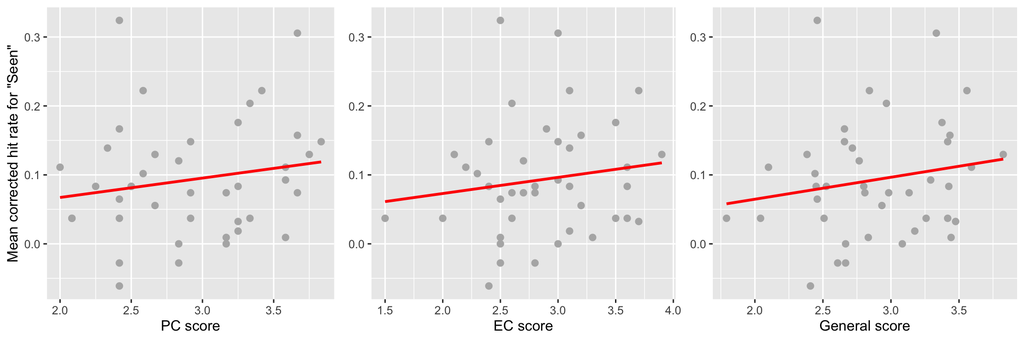

```
##
##  Pearson's product-moment correlation
##
## data:  outside.hit.rate.trait$meanSrcAcc and outside.hit.rate.trait$PC
## t = 1.1071, df = 39, p-value = 0.275
## alternative hypothesis: true correlation is not equal to 0
## 95 percent confidence interval:
##  -0.1406485  0.4576299
## sample estimates:
##       cor
## 0.1745551
```

```
##
##  Pearson's product-moment correlation
##
## data:  outside.hit.rate.trait$meanSrcAcc and outside.hit.rate.trait$EC
## t = 0.92326, df = 39, p-value = 0.3615
## alternative hypothesis: true correlation is not equal to 0
## 95 percent confidence interval:
##  -0.1690043  0.4343573
## sample estimates:
##       cor
## 0.1462503
```

```
##
##  Pearson's product-moment correlation
##
## data:  outside.hit.rate.trait$meanSrcAcc and outside.hit.rate.trait$GN
## t = 1.1322, df = 39, p-value = 0.2645
## alternative hypothesis: true correlation is not equal to 0
## 95 percent confidence interval:
##  -0.1367704  0.4607503
## sample estimates:
##      cor
## 0.178386
```

## 3.2 Inside

### 3.2.1 Item recollection

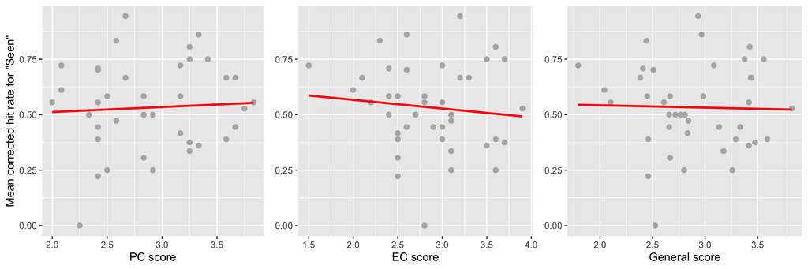

```
##
##  Pearson's product-moment correlation
##
## data:  inside.hit.rate.trait$meanSAcc and inside.hit.rate.trait$PC
## t = 0.37743, df = 39, p-value = 0.7079
## alternative hypothesis: true correlation is not equal to 0
## 95 percent confidence interval:
##  -0.2520004  0.3612724
## sample estimates:
##        cor
## 0.06032704
```

```
##
##  Pearson's product-moment correlation
##
## data:  inside.hit.rate.trait$meanSAcc and inside.hit.rate.trait$EC
## t = -0.66609, df = 39, p-value = 0.5093
## alternative hypothesis: true correlation is not equal to 0
## 95 percent confidence interval:
##  -0.4006362  0.2083920
## sample estimates:
##       cor
## -0.106058
```

```
##
##  Pearson's product-moment correlation
##
## data:  inside.hit.rate.trait$meanSAcc and inside.hit.rate.trait$GN
## t = -0.16074, df = 39, p-value = 0.8731
## alternative hypothesis: true correlation is not equal to 0
## 95 percent confidence interval:
##  -0.3307627  0.2841693
## sample estimates:
##         cor
## -0.02573059
```

### 3.2.2 Source memory

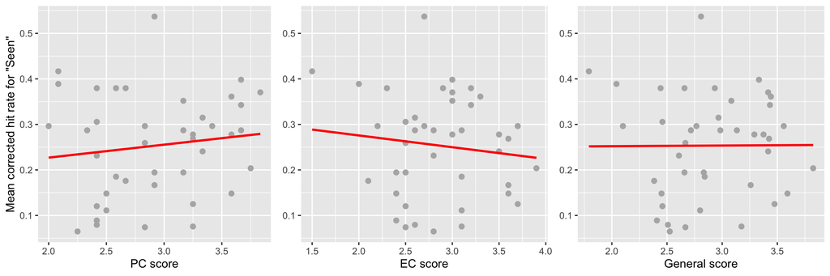

```
##
##  Pearson's product-moment correlation
##
## data:  inside.hit.rate.trait$meanSrcAcc and inside.hit.rate.trait$PC
## t = 0.82889, df = 39, p-value = 0.4122
## alternative hypothesis: true correlation is not equal to 0
## 95 percent confidence interval:
##  -0.1835039  0.4221374
## sample estimates:
##       cor
## 0.1315746
```

```
##
##  Pearson's product-moment correlation
##
## data:  inside.hit.rate.trait$meanSrcAcc and inside.hit.rate.trait$EC
## t = -0.75621, df = 39, p-value = 0.4541
## alternative hypothesis: true correlation is not equal to 0
## 95 percent confidence interval:
##  -0.4126028  0.1946371
## sample estimates:
##        cor
## -0.1202117
```

```
##
##  Pearson's product-moment correlation
##
## data:  inside.hit.rate.trait$meanSrcAcc and inside.hit.rate.trait$GN
## t = 0.036688, df = 39, p-value = 0.9709
## alternative hypothesis: true correlation is not equal to 0
## 95 percent confidence interval:
##  -0.3023222  0.3129595
## sample estimates:
##         cor
## 0.005874675
```

# 4 Relationship between trait score and memory performance within *Novel* rooms

Here *memory performance* refers to the average corrected hit rate for “seen” response for items and average corrected hit rate for source memory.

## 4.1 Outside

### 4.1.1 Item recollection

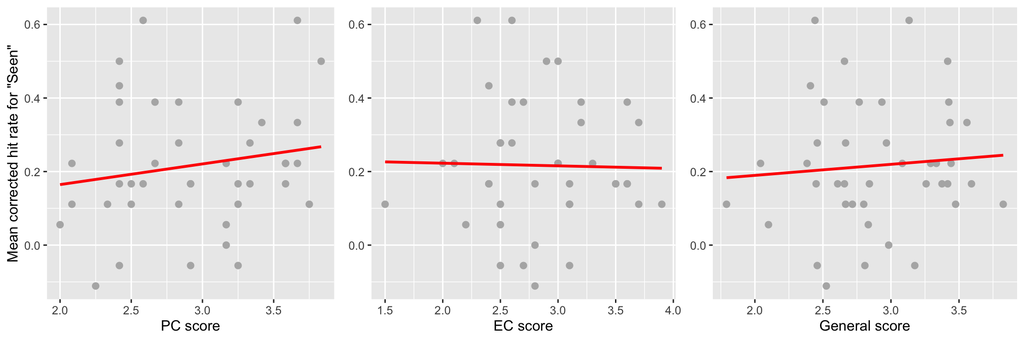

```
##
##  Pearson's product-moment correlation
##
## data:  outside.hit.rate.trait.novel$meanSAcc and outside.hit.rate.trait.novel$PC
## t = 1.0824, df = 39, p-value = 0.2857
## alternative hypothesis: true correlation is not equal to 0
## 95 percent confidence interval:
##  -0.1444589  0.4545495
## sample estimates:
##       cor
## 0.1707815
```

```
##
##  Pearson's product-moment correlation
##
## data:  outside.hit.rate.trait.novel$meanSAcc and outside.hit.rate.trait.novel$EC
## t = -0.13742, df = 39, p-value = 0.8914
## alternative hypothesis: true correlation is not equal to 0
## 95 percent confidence interval:
##  -0.3274338  0.2875975
## sample estimates:
##         cor
## -0.02199945
```

```
##
##  Pearson's product-moment correlation
##
## data:  outside.hit.rate.trait.novel$meanSAcc and outside.hit.rate.trait.novel$GN
## t = 0.51643, df = 39, p-value = 0.6085
## alternative hypothesis: true correlation is not equal to 0
## 95 percent confidence interval:
##  -0.2310964  0.3804185
## sample estimates:
##       cor
## 0.0824134
```

### 4.1.2 Source memory

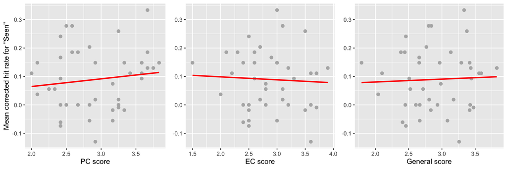

```
##
##  Pearson's product-moment correlation
##
## data:  outside.hit.rate.trait.novel$meanSrcAcc and outside.hit.rate.trait.novel$PC
## t = 0.81501, df = 39, p-value = 0.42
## alternative hypothesis: true correlation is not equal to 0
## 95 percent confidence interval:
##  -0.1856330  0.4203243
## sample estimates:
##      cor
## 0.129408
```

```
##
##  Pearson's product-moment correlation
##
## data:  outside.hit.rate.trait.novel$meanSrcAcc and outside.hit.rate.trait.novel$EC
## t = -0.31494, df = 39, p-value = 0.7545
## alternative hypothesis: true correlation is not equal to 0
## 95 percent confidence interval:
##  -0.3525541  0.2613333
## sample estimates:
##         cor
## -0.05036655
```

```
##
##  Pearson's product-moment correlation
##
## data:  outside.hit.rate.trait.novel$meanSrcAcc and outside.hit.rate.trait.novel$GN
## t = 0.27283, df = 39, p-value = 0.7864
## alternative hypothesis: true correlation is not equal to 0
## 95 percent confidence interval:
##  -0.2675979  0.3466416
## sample estimates:
##        cor
## 0.04364576
```

## 4.2 Inside

### 4.2.1 Item recollection

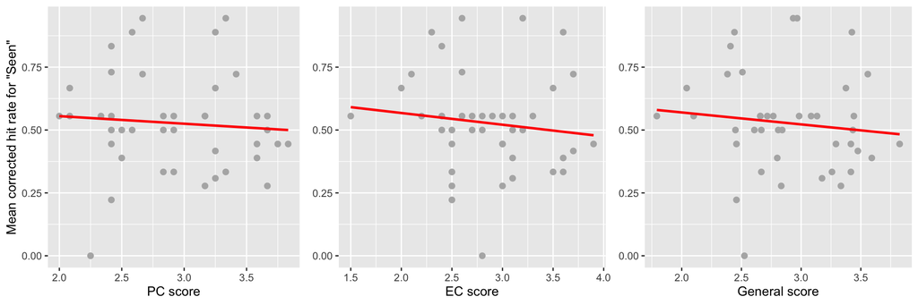

```
##
##  Pearson's product-moment correlation
##
## data:  inside.hit.rate.trait.novel$meanSAcc and inside.hit.rate.trait.novel$PC
## t = -0.49409, df = 39, p-value = 0.624
## alternative hypothesis: true correlation is not equal to 0
## 95 percent confidence interval:
##  -0.3773646  0.2344690
## sample estimates:
##         cor
## -0.07887073
```

```
##
##  Pearson's product-moment correlation
##
## data:  inside.hit.rate.trait.novel$meanSAcc and inside.hit.rate.trait.novel$EC
## t = -0.77184, df = 39, p-value = 0.4449
## alternative hypothesis: true correlation is not equal to 0
## 95 percent confidence interval:
##  -0.4146619  0.1922458
## sample estimates:
##        cor
## -0.1226593
```

```
##
##  Pearson's product-moment correlation
##
## data:  inside.hit.rate.trait.novel$meanSAcc and inside.hit.rate.trait.novel$GN
## t = -0.70496, df = 39, p-value = 0.485
## alternative hypothesis: true correlation is not equal to 0
## 95 percent confidence interval:
##  -0.4058170  0.2024664
## sample estimates:
##        cor
## -0.1121711
```

### 4.2.2 Source memory

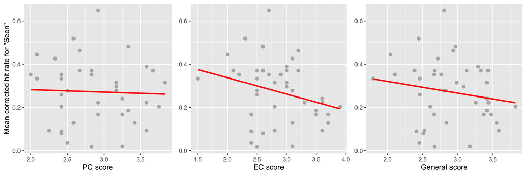

```
##
##  Pearson's product-moment correlation
##
## data:  inside.hit.rate.trait.novel$meanSrcAcc and inside.hit.rate.trait.novel$PC
## t = -0.25284, df = 39, p-value = 0.8017
## alternative hypothesis: true correlation is not equal to 0
## 95 percent confidence interval:
##  -0.3438246  0.2705645
## sample estimates:
##         cor
## -0.04045325
```

```
##
##  Pearson's product-moment correlation
##
## data:  inside.hit.rate.trait.novel$meanSrcAcc and inside.hit.rate.trait.novel$EC
## t = -1.7843, df = 39, p-value = 0.08216
## alternative hypothesis: true correlation is not equal to 0
## 95 percent confidence interval:
##  -0.53698541  0.03597091
## sample estimates:
##        cor
## -0.2747197
```

```
##
##  Pearson's product-moment correlation
##
## data:  inside.hit.rate.trait.novel$meanSrcAcc and inside.hit.rate.trait.novel$GN
## t = -1.1147, df = 39, p-value = 0.2718
## alternative hypothesis: true correlation is not equal to 0
## 95 percent confidence interval:
##  -0.4585777  0.1394724
## sample estimates:
##        cor
## -0.1757178
```

# 5 Relationship between trait score and curiosity ratings between *Familiar* and *Novel* rooms

## 5.1 See whether the curiosity ratings are significantly different between *novel* and *familiar* rooms

The average curiosity rating for the *novel* rooms is 5.39 (SD = $\pm$ 1.3).

The average curiosity rating for the *familiar* rooms is 3.46 (SD = $\pm$ 1.49).

```
##
##  One Sample t-test
##
## data:  outside.hit.rate.trait.diff$diffRating
## t = 5.0341, df = 40, p-value = 1.062e-05
## alternative hypothesis: true mean is not equal to 0
## 95 percent confidence interval:
##  1.155687 2.706102
## sample estimates:
## mean of x
##  1.930894
```

## 5.2 See whether the difference in curiosity ratings are significantly correlated with trait scores

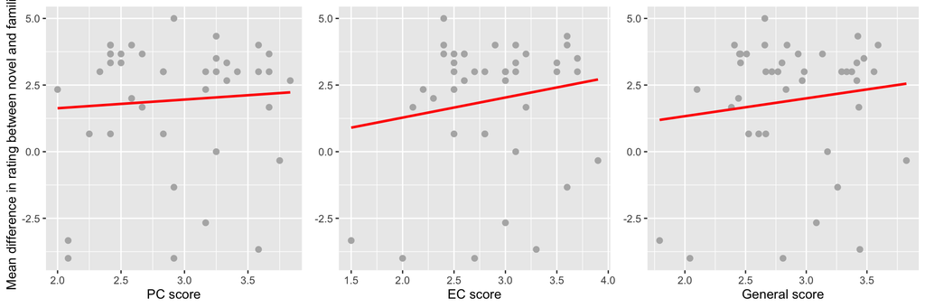

```
##
##  Pearson's product-moment correlation
##
## data:  outside.hit.rate.trait.diff$diffRating and outside.hit.rate.trait.diff$PC
## t = 0.43463, df = 39, p-value = 0.6662
## alternative hypothesis: true correlation is not equal to 0
## 95 percent confidence interval:
##  -0.2434214  0.3691931
## sample estimates:
##        cor
## 0.06942848
```

```
##
##  Pearson's product-moment correlation
##
## data:  outside.hit.rate.trait.diff$diffRating and outside.hit.rate.trait.diff$EC
## t = 1.0252, df = 39, p-value = 0.3116
## alternative hypothesis: true correlation is not equal to 0
## 95 percent confidence interval:
##  -0.1532923  0.4473530
## sample estimates:
##      cor
## 0.161998
```

```
##
##  Pearson's product-moment correlation
##
## data:  outside.hit.rate.trait.diff$diffRating and outside.hit.rate.trait.diff$GN
## t = 0.81166, df = 39, p-value = 0.4219
## alternative hypothesis: true correlation is not equal to 0
## 95 percent confidence interval:
##  -0.1861452  0.4198874
## sample estimates:
##       cor
## 0.1288863
```

### 5.2.1 Looking at the trait-rating correlation separately for the *novel* and *familiar* rooms

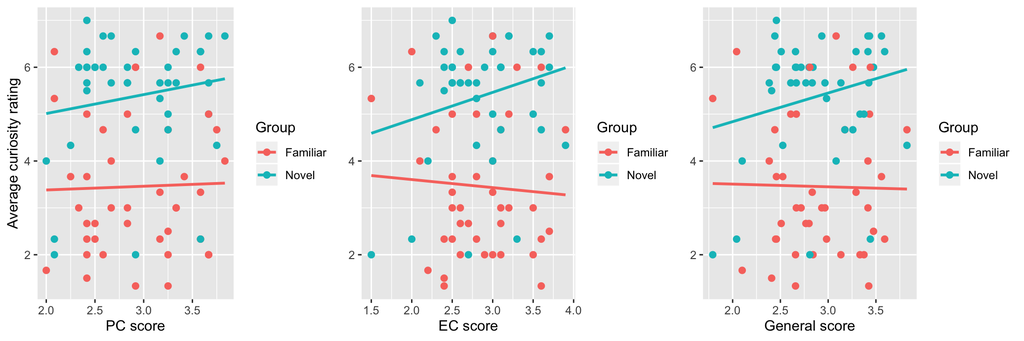

# 6 Relationship between trait score and performance differences between *Familiar* and *Novel* rooms

Here *performance difference* refers to difference in item recollection and source memory between the *novel* and *familiar* rooms (*novel* - *familiar*).

## 6.1 Outside

### 6.1.1 Item recollection

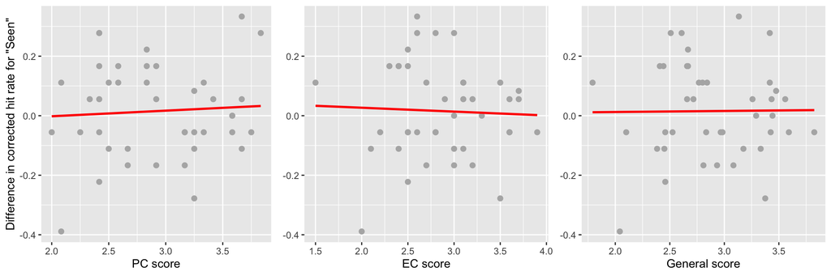

### 6.1.2 Source memory

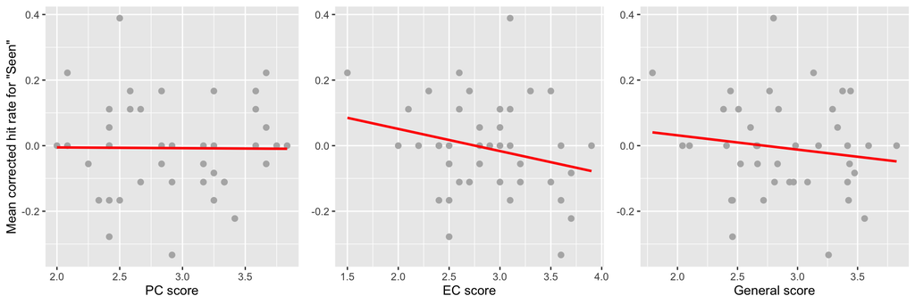

```
##
##  Pearson's product-moment correlation
##
## data:  outside.hit.rate.trait.diff$diffSrcAcc and outside.hit.rate.trait.diff$PC
## t = -0.051811, df = 39, p-value = 0.9589
## alternative hypothesis: true correlation is not equal to 0
## 95 percent confidence interval:
##  -0.3151423  0.3001203
## sample estimates:
##         cor
## -0.00829617
```

```
##
##  Pearson's product-moment correlation
##
## data:  outside.hit.rate.trait.diff$diffSrcAcc and outside.hit.rate.trait.diff$EC
## t = -1.5852, df = 39, p-value = 0.121
## alternative hypothesis: true correlation is not equal to 0
## 95 percent confidence interval:
##  -0.51471737  0.06667089
## sample estimates:
##        cor
## -0.2460259
```

```
##
##  Pearson's product-moment correlation
##
## data:  outside.hit.rate.trait.diff$diffSrcAcc and outside.hit.rate.trait.diff$GN
## t = -0.89508, df = 39, p-value = 0.3762
## alternative hypothesis: true correlation is not equal to 0
## 95 percent confidence interval:
##  -0.4307276  0.1733386
## sample estimates:
##        cor
## -0.1418779
```

## 6.2 Inside

### 6.2.1 Item recollection

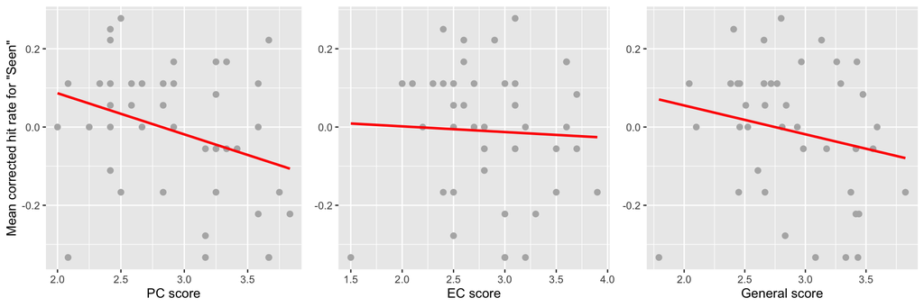

```
##
##  Pearson's product-moment correlation
##
## data:  inside.hit.rate.trait.diff$diffSAcc and inside.hit.rate.trait.diff$PC
## t = -2.1114, df = 39, p-value = 0.0412
## alternative hypothesis: true correlation is not equal to 0
## 95 percent confidence interval:
##  -0.57160597 -0.01400775
## sample estimates:
##       cor
## -0.320278
```

```
##
##  Pearson's product-moment correlation
##
## data:  inside.hit.rate.trait.diff$diffSAcc and inside.hit.rate.trait.diff$EC
## t = -0.2789, df = 39, p-value = 0.7818
## alternative hypothesis: true correlation is not equal to 0
## 95 percent confidence interval:
##  -0.3474955  0.2666963
## sample estimates:
##         cor
## -0.04461471
```

```
##
##  Pearson's product-moment correlation
##
## data:  inside.hit.rate.trait.diff$diffSAcc and inside.hit.rate.trait.diff$GN
## t = -1.2912, df = 39, p-value = 0.2042
## alternative hypothesis: true correlation is not equal to 0
## 95 percent confidence interval:
##  -0.4802085  0.1121671
## sample estimates:
##        cor
## -0.2024703
```

### 6.2.2 Source memory

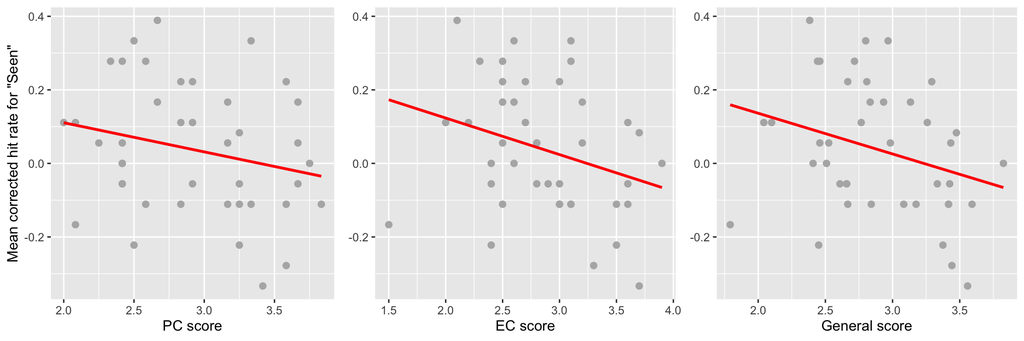

```
##
##  Pearson's product-moment correlation
##
## data:  inside.hit.rate.trait.diff$diffSrcAcc and inside.hit.rate.trait.diff$PC
## t = -1.5035, df = 39, p-value = 0.1408
## alternative hypothesis: true correlation is not equal to 0
## 95 percent confidence interval:
##  -0.5053308  0.0792902
## sample estimates:
##        cor
## -0.2340701
```

```
##
##  Pearson's product-moment correlation
##
## data:  inside.hit.rate.trait.diff$diffSrcAcc and inside.hit.rate.trait.diff$EC
## t = -1.93, df = 39, p-value = 0.06091
## alternative hypothesis: true correlation is not equal to 0
## 95 percent confidence interval:
##  -0.55270885  0.01362215
## sample estimates:
##        cor
## -0.2952657
```

```
##
##  Pearson's product-moment correlation
##
## data:  inside.hit.rate.trait.diff$diffSrcAcc and inside.hit.rate.trait.diff$GN
## t = -1.9247, df = 39, p-value = 0.06158
## alternative hypothesis: true correlation is not equal to 0
## 95 percent confidence interval:
##  -0.55215029  0.01442587
## sample estimates:
##        cor
## -0.2945317
```